# EDA

## Looking at ATP (Men’s) matches

```r
data(atp_matches)

gs <- atp_matches %>% filter(tourney_level == "Grand Slams" & year >= 2013)
sort(unique(gs$tourney_name))
```

```
## [1] "Australian Open" "Roland Garros"   "Us Open"         "US Open"
## [5] "Wimbledon"
```

```r
colnames(gs)
```

```
##  [1] "tourney_id"         "tourney_name"       "surface"
##  [4] "draw_size"          "tourney_level"      "match_num"
##  [7] "winner_id"          "winner_seed"        "winner_entry"
## [10] "winner_name"        "winner_hand"        "winner_ht"
## [13] "winner_ioc"         "winner_age"         "winner_rank"
## [16] "winner_rank_points" "loser_id"           "loser_seed"
## [19] "loser_entry"        "loser_name"         "loser_hand"
## [22] "loser_ht"           "loser_ioc"          "loser_age"
## [25] "loser_rank"         "loser_rank_points"  "score"
## [28] "best_of"            "round"              "minutes"
## [31] "w_ace"              "w_df"               "w_svpt"
## [34] "w_1stIn"            "w_1stWon"           "w_2ndWon"
## [37] "w_SvGms"            "w_bpSaved"          "w_bpFaced"
## [40] "l_ace"              "l_df"               "l_svpt"
## [43] "l_1stIn"            "l_1stWon"           "l_2ndWon"
## [46] "l_SvGms"            "l_bpSaved"          "l_bpFaced"
## [49] "W1"                 "W2"                 "W3"
## [52] "W4"                 "W5"                 "L1"
## [55] "L2"                 "L3"                 "L4"
## [58] "L5"                 "Retirement"         "WTB1"
## [61] "LTB1"               "WTB2"               "LTB2"
## [64] "WTB3"               "LTB3"               "WTB4"
## [67] "LTB4"               "WTB5"               "LTB5"
## [70] "tourney_start_date" "year"               "match_id"
```

```r
## Add new column of points won
gs <- gs %>% mutate(w_pointswon = w_1stWon + w_2ndWon + l_svpt - l_1stWon - l_2ndWon)
gs <- gs %>% mutate(l_pointswon = l_1stWon + l_2ndWon + w_svpt - w_1stWon - w_2ndWon)
gs <- gs %>% mutate(w_morepts = w_pointswon >= l_pointswon)
n_correct <- sum(gs$w_morepts, na.rm = TRUE)
na_pt_indices <- which(is.na(gs$w_morepts))
n_correct / (nrow(gs) - length(na_pt_indices)) # more points won tells us who won >95% of the time
```

```
## [1] 0.9570783
```

```r
gs[na_pt_indices,]  ## All NA are straight up retirements so not really NA
```

```
##      tourney_id    tourney_name surface draw_size tourney_level match_num
## 195    2013-520   Roland Garros    Clay       128   Grand Slams        68
## 335    2013-540       Wimbledon   Grass       128   Grand Slams        81
## 346    2013-540       Wimbledon   Grass       128   Grand Slams        92
## 617    2014-580 Australian Open    Hard       128   Grand Slams       109
## 977    2014-560         US Open    Hard       128   Grand Slams        88
## 990    2014-560         US Open    Hard       128   Grand Slams       101
## 1217   2015-520   Roland Garros    Clay       128   Grand Slams        74
## 1248   2015-520   Roland Garros    Clay       128   Grand Slams       105
## 1752   2016-520   Roland Garros    Clay       128   Grand Slams       101
## 1863   2016-540       Wimbledon   Grass       128   Grand Slams        85
## 1970   2016-560         Us Open    Hard       128   Grand Slams        65
##      winner_id winner_seed winner_entry           winner_name winner_hand
## 195     104259          16              Philipp Kohlschreiber           R
## 335     103997          NA                       Lukasz Kubot           R
```

[output cut: 105 more lines]

```r
incorrect_inds <- which(!gs$w_morepts)
table(gs[incorrect_inds, "tourney_name"])
```

```
##
## Australian Open   Roland Garros         Us Open         US Open
##              38              21              10              21
##       Wimbledon
##              24
```

```r
table(gs[incorrect_inds, "Retirement"])
```

```
##
## FALSE  TRUE
##   104    10
```

Australian Open with most wins with loser winning more points than winner. Of all the matches where the winners won fewer points than the losers, only 10 were retirements. Which means you are more likely to quit when you are down (10 night before).

```r
library(forcats)
library(stringr)
## Combine US Open
gs$tournament <- factor(gs$tourney_name)
gs$tournament <- gs$tournament %>% fct_collapse("US Open" = c("US Open", "Us Open"))

## Extract te number of sets in each match
no_ret <- gsub(" RET", "", gs$score)
set_scores <- str_split(no_ret, " ")
n_sets <- sapply(set_scores, length)
gs$n_sets <- n_sets
```

```r
library(ggplot2)
library(reshape2)

g <- ggplot(data = gs, aes(x = w_pointswon)) + geom_histogram()
g
```

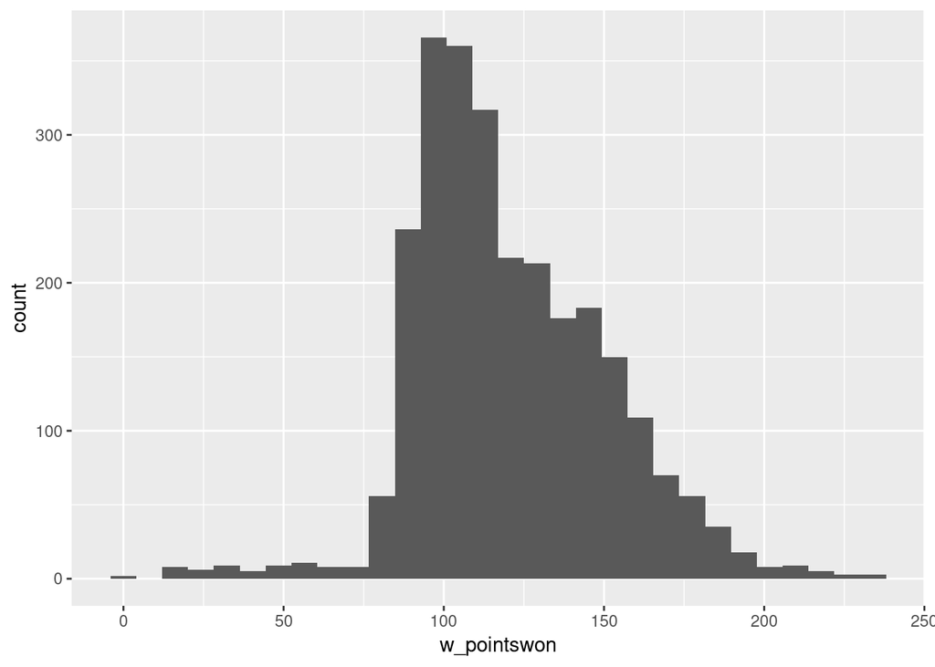

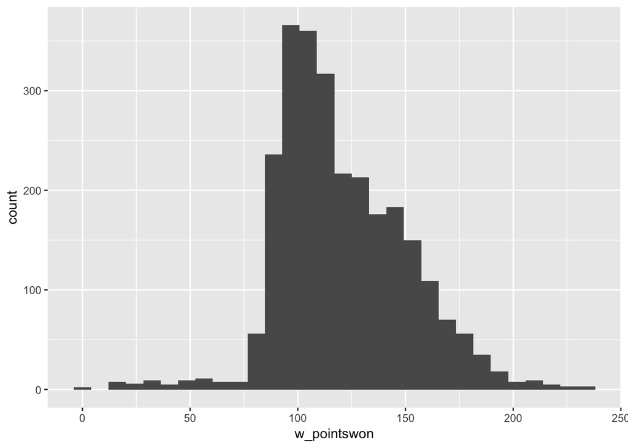

```r
g2 <- ggplot(data = gs, aes(x = w_pointswon)) +
    geom_histogram(aes(y=..density..)) +
    facet_grid(~tournament)
g2
```

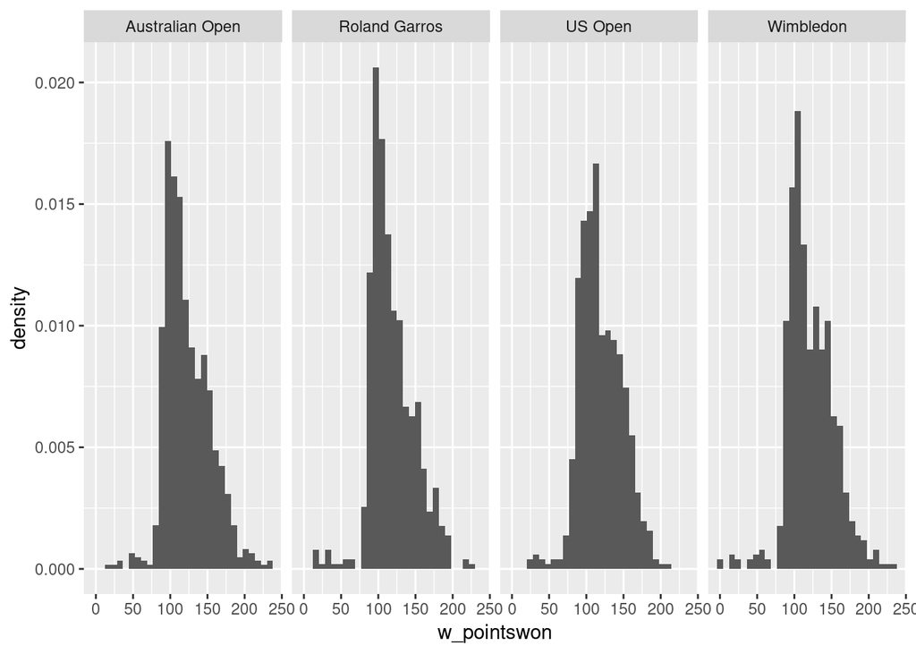

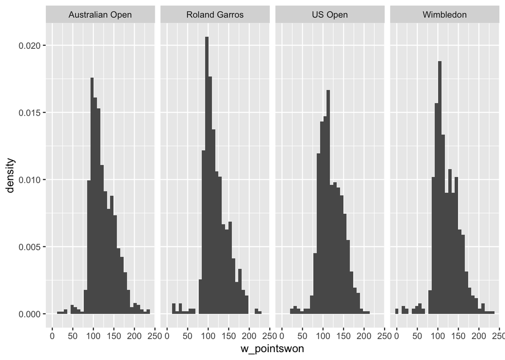

```r
##
bp <- ggplot(data = gs, aes(x = n_sets)) +
    geom_bar(aes(y = ..prop..)) +
    facet_grid(~tournament)
bp
```

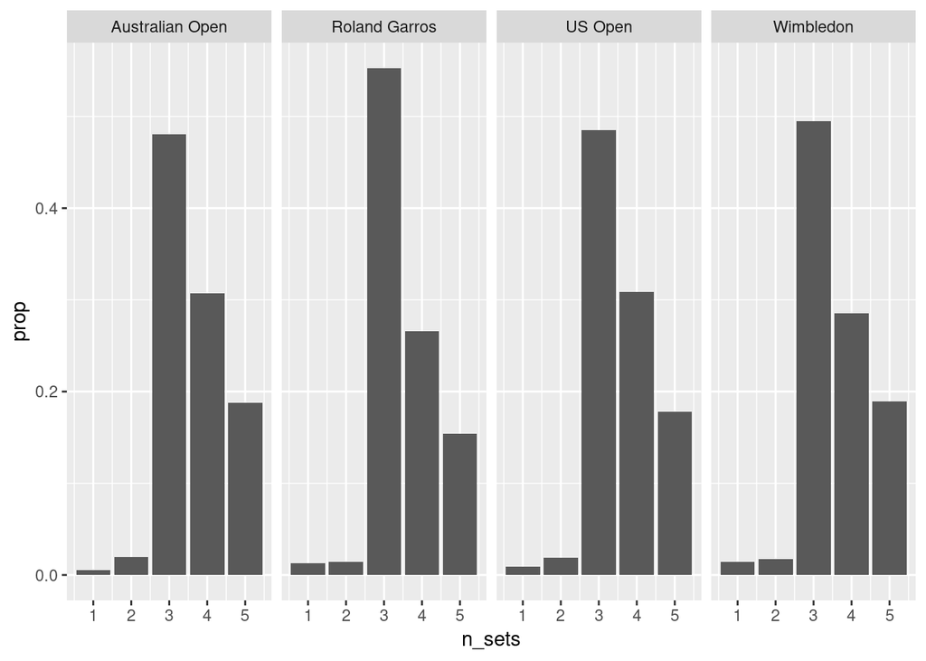

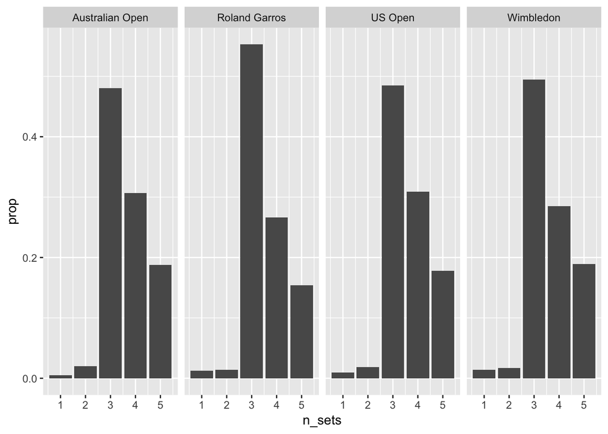

```r
g3 <- ggplot(data = gs, aes(x = w_pointswon)) +
    geom_histogram(aes(y=..density..)) +
    facet_grid(n_sets~tournament)
g3
```

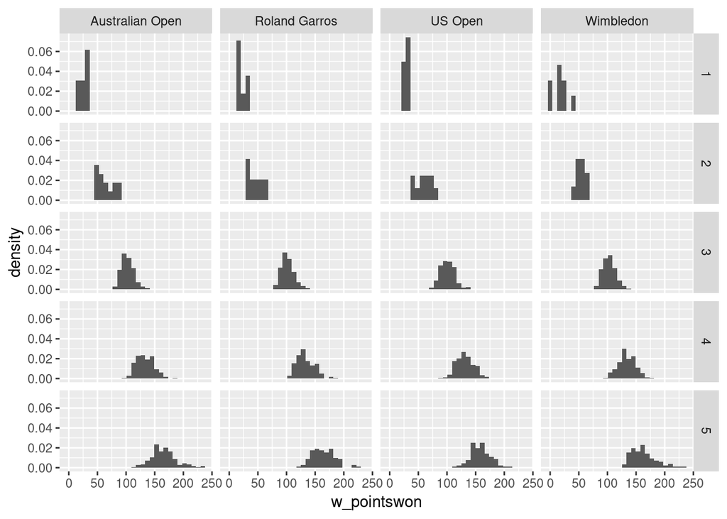

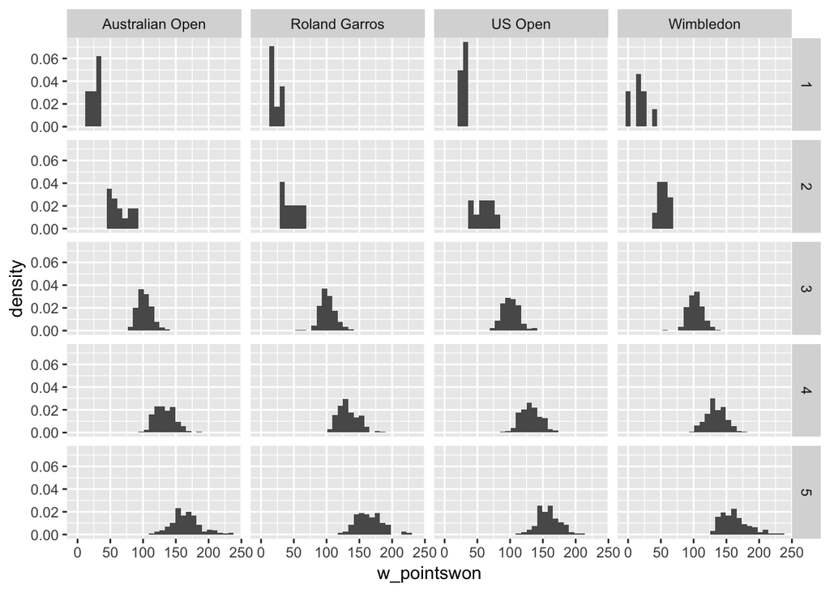

```r
## Moving to boxplots
g2 <- ggplot(data = gs,
             aes(x = tournament, y= minutes,
                            group = tournament, col = tournament)) +
    geom_boxplot(size = 1)  + facet_grid(~n_sets)
g2
```

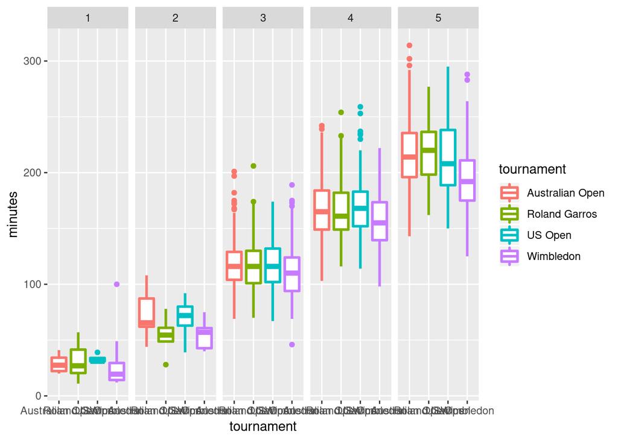

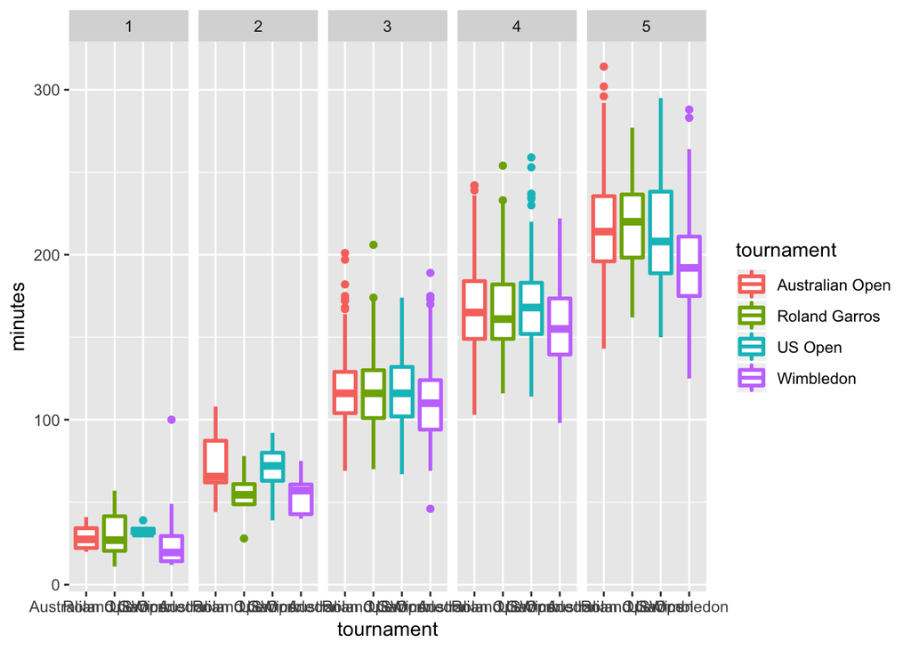

```r
## More boxplots
g2 <- ggplot(data = gs,
             aes(x = winner_ioc,
                            group = tournament, fill = tournament)) +
    geom_bar(aes(y=..prop..), size = 1)  + facet_grid(~tournament) +
    theme(axis.text.x = element_text(angle = 90, hjust = 1)) + coord_flip()
g2
```

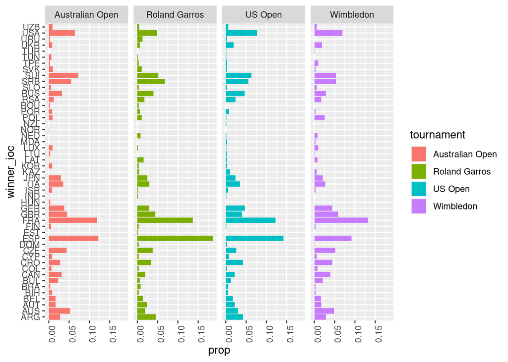

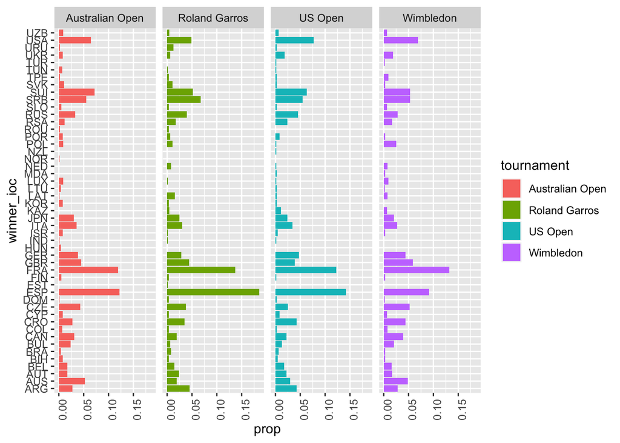

```r
## RG has least amount of double faults
```

[output not shown]

- Find games won and lost
- Find service games won/lost
- Look at retirements by court
- Look at wins by country by court
- Find number of tiebreaks by court
- Need to normalize wins by country by n_players in tournament (but both are interesting)
- Look at gs point by point
- Need to get French Open 2018 results
- Get Women’s data and combine it
- Look atGS_point_by_point. Is it complete? Is it complete for rafa, serena, fed?
- Facet by round
- Do above but instead predict winner games, or winner sets, loser games, or loser sets
- get hex colors of GS